# R Notebook

upload libraries

```r
library(CodeClanData)
library(ggplot2)
```

Take the data in the dataset qb_revenue_breakdown and make a stacked bar chart showing the sources of revenue across the two years in the dataset

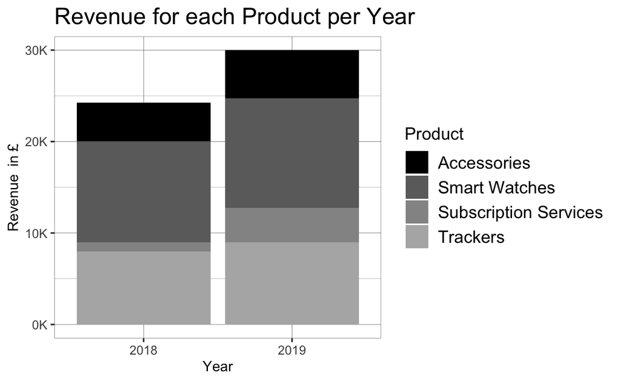

```r
ggplot(qb_revenue_breakdown) +
  aes(x = Year, y = Revenue/1000, fill = Product) +
  geom_bar(stat = "identity") +
  labs(x = "Year",
       y = "Revenue  in £",
       title = "Revenue for each Product per Year") +
  scale_fill_grey(start = 0, end = 0.7) +
  scale_y_continuous(labels = scales::comma_format(suffix = "K")) +
  theme(
    panel.background = element_rect(fill = "white"),
    axis.title = element_text(size = 10),
    plot.title = element_text(size = 16),
    legend.title = element_text(size = 12),
    legend.text = element_text(size = 12),
    panel.grid = element_line(colour = "grey25", size = 0.1),
    panel.border = element_rect(colour = "grey25", size = 0.2, fill = NA)
  )
```

Make a line chart showing monthly sales of the “flagship product” - the KwikBit Unit1 - over the last year.

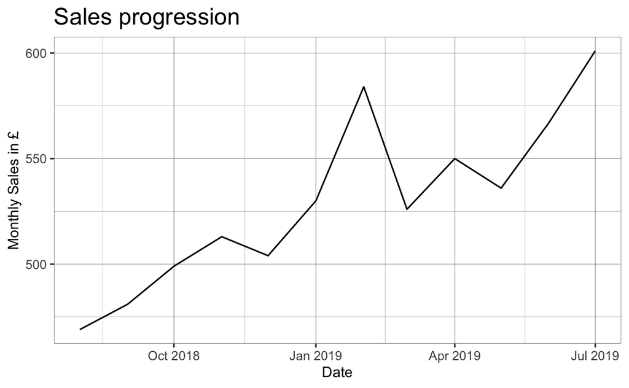

```r
ggplot(subset(qb_monthly_sales, Cashflow == "Kwikbit Unit 1 Sales")) +
  aes(x = Date, y = as.integer(Amount)) +
  geom_line() +
  labs(x = "Date",
       y = "Monthly Sales in £",
       title = "Sales progression") +
  theme(
    panel.background = element_rect(fill = "white"),
    panel.grid = element_line(colour = "grey25", size = 0.1),
    panel.border = element_rect(colour = "grey25", size = 0.2, fill = NA),
    axis.title = element_text(size = 10),
    plot.title = element_text(size = 16)
    )
```

Make a line chart showing monthly revenue and costs over the last year.

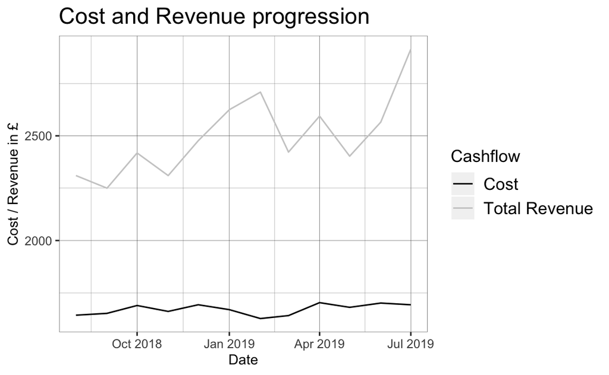

```r
revenue_and_costs <- subset(qb_monthly_sales, Cashflow != "Kwikbit Unit 1 Sales")

ggplot(revenue_and_costs) +
  aes(x = Date, y = Amount, colour = Cashflow, group = Cashflow) +
  geom_line() +
  scale_colour_manual(values = c("Cost" = "grey1",
                                 "Total Revenue" = "grey80")) +
  labs(x = "Date",
       y = "Cost / Revenue in £",
       title = "Cost and Revenue progression") +
  theme(
    panel.background = element_rect(fill = "white"),
    panel.grid = element_line(colour = "grey25", size = 0.1),
    panel.border = element_rect(colour = "grey25", size = 0.2, fill = NA),
    axis.title = element_text(size = 10),
    plot.title = element_text(size = 16),
    legend.title = element_text(size = 12),
    legend.text = element_text(size = 12)
    )
```

Show annual sales of personal fitness trackers over the last 5 years broken down by company as a ribbon plot (use geom_area). This data is in qb_competitors.

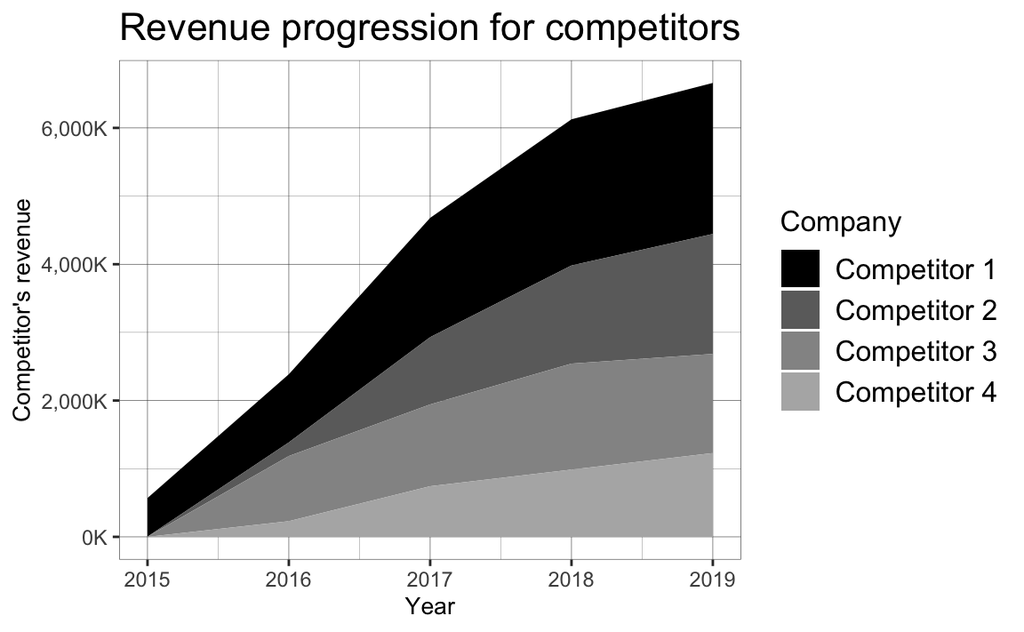

```r
ggplot(qb_competitors) +
  aes(x = Year, y = Revenue/1000, fill = Company) +
  geom_area() +
  scale_fill_grey(start = 0, end = 0.7) +
  scale_y_continuous(labels = scales::comma_format(suffix = "K")) +
  labs(x = "Year",
       y = "Competitor's revenue",
       title = "Revenue progression for competitors") +
  theme(
    panel.background = element_rect(fill = "white"),
    panel.grid = element_line(colour = "grey25", size = 0.1),
    panel.border = element_rect(colour = "grey25", size = 0.2, fill = NA),
    axis.title = element_text(size = 10),
    plot.title = element_text(size = 16),
    legend.title = element_text(size = 12),
    legend.text = element_text(size = 12)
    )
```

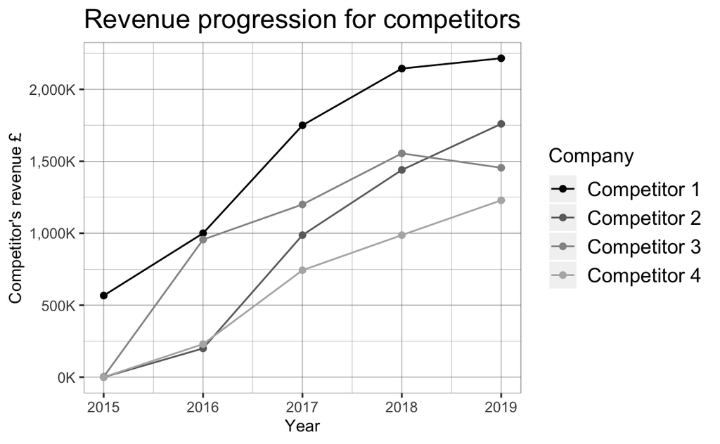

```r
ggplot(qb_competitors) +
  aes(x = Year, y = Revenue/1000, colour = Company) +
  geom_line() +
  geom_point() +
  scale_colour_grey(start = 0, end = 0.7) +
  scale_y_continuous(labels = scales::comma_format(suffix = "K")) +
  labs(x = "Year",
       y = "Competitor's revenue £",
       title = "Revenue progression for competitors") +
  theme(
    panel.background = element_rect(fill = "white"),
    panel.grid = element_line(colour = "grey25", size = 0.1),
    panel.border = element_rect(colour = "grey25", size = 0.2, fill = NA),
    axis.title = element_text(size = 10),
    plot.title = element_text(size = 16),
    legend.title = element_text(size = 12),
    legend.text = element_text(size = 12)
    )
```

Now the company wants to compare the number of steps that their device counts vs. their competitors. Make a line graph of the number of steps throughout time, and use faceting to compare between individuals and people. Polish this plot like the others.

```r
qb_device_data
```

|  | device | id | hours | mins | counts |
| --- | --- | --- | --- | --- | --- |
| 361 | qikbit1 | person1 | 6 | 0 | 0 |
| 362 | qikbit1 | person1 | 6 | 1 | 0 |
| 363 | qikbit1 | person1 | 6 | 2 | 0 |
| 364 | qikbit1 | person1 | 6 | 3 | 0 |
| 365 | qikbit1 | person1 | 6 | 4 | 0 |
| 366 | qikbit1 | person1 | 6 | 5 | 0 |
| 367 | qikbit1 | person1 | 6 | 6 | 0 |
| 368 | qikbit1 | person1 | 6 | 7 | 0 |
| 369 | qikbit1 | person1 | 6 | 8 | 0 |
| 370 | qikbit1 | person1 | 6 | 9 | 0 |

[output cut: 990 more lines]

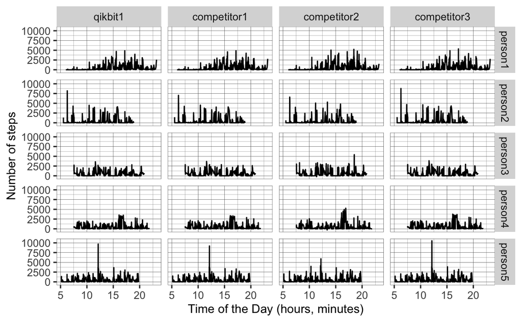

```r
qb_device_data$time <- as.numeric(paste0(qb_device_data$hours,".",
                                  qb_device_data$mins))
ggplot(qb_device_data) +
  aes(x = time, y = counts,) +
  geom_line() +
  facet_grid(id ~ device) +
  labs(
    x = "Time of the Day (hours, minutes)",
    y = "Number of steps",
    Title = "Number of steps for each person"
  ) +
  theme(
    panel.background = element_rect(fill = "white"),
    panel.grid = element_line(colour = "grey25", size = 0.1),
    panel.border = element_rect(colour = "grey25", size = 0.2, fill = NA),
    axis.title = element_text(size = 10),
    plot.title = element_text(size = 16),
    legend.title = element_text(size = 12),
    legend.text = element_text(size = 12)
    )
```

Extend Q2 to include projected sales for the next 3 years on the assumption sales increase at 10% pa each year from 1st August. You may assume sales in other months can be interpolated (i.e. straight line between Augusts).

```r
qb_monthly_sales
```

| Date | Cashflow | Amount |
| --- | --- | --- |
| 2019-07-01 | Kwikbit Unit 1 Sales | 601.74 |
| 2019-06-01 | Kwikbit Unit 1 Sales | 567.89 |
| 2019-05-01 | Kwikbit Unit 1 Sales | 536.00 |
| 2019-04-01 | Kwikbit Unit 1 Sales | 550.78 |
| 2019-03-01 | Kwikbit Unit 1 Sales | 526.03 |
| 2019-02-01 | Kwikbit Unit 1 Sales | 584.22 |
| 2019-01-01 | Kwikbit Unit 1 Sales | 530.76 |
| 2018-12-01 | Kwikbit Unit 1 Sales | 504.80 |
| 2018-11-01 | Kwikbit Unit 1 Sales | 513.67 |
| 2018-10-01 | Kwikbit Unit 1 Sales | 499.99 |

[output cut: 26 more lines]

```r
df <- subset(qb_monthly_sales, Cashflow == "Kwikbit Unit 1 Sales")
df
```

|  | Date | Cashflow | Amount |
| --- | --- | --- | --- |
| 1 | 2019-07-01 | Kwikbit Unit 1 Sales | 601.74 |
| 2 | 2019-06-01 | Kwikbit Unit 1 Sales | 567.89 |
| 3 | 2019-05-01 | Kwikbit Unit 1 Sales | 536.00 |
| 4 | 2019-04-01 | Kwikbit Unit 1 Sales | 550.78 |
| 5 | 2019-03-01 | Kwikbit Unit 1 Sales | 526.03 |
| 6 | 2019-02-01 | Kwikbit Unit 1 Sales | 584.22 |
| 7 | 2019-01-01 | Kwikbit Unit 1 Sales | 530.76 |
| 8 | 2018-12-01 | Kwikbit Unit 1 Sales | 504.80 |
| 9 | 2018-11-01 | Kwikbit Unit 1 Sales | 513.67 |
| 10 | 2018-10-01 | Kwikbit Unit 1 Sales | 499.99 |

[output cut: 2 more lines]

```r
sales <- c(qb_monthly_sales[12, 3]*1.1,
           qb_monthly_sales[12, 3]*1.1*1.1,
           qb_monthly_sales[12, 3]*1.1*1.1*1.1)
date <- as.Date(c("2019-08-01", "2020-08-01", "2021-08-01"))

future_sale <- data.frame(date = date,
                          sales = sales)
```

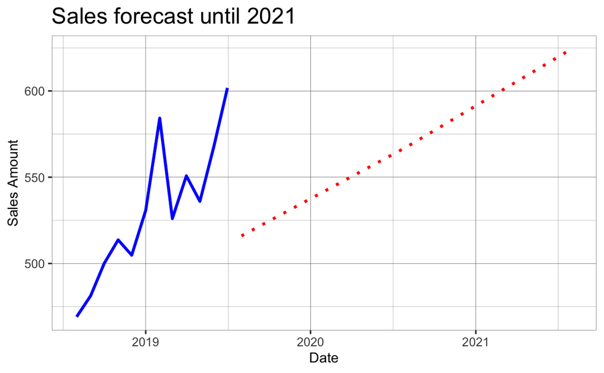

```r
ggplot(subset(qb_monthly_sales, Cashflow == "Kwikbit Unit 1 Sales")) +
  geom_line(aes(x = Date, y = Amount),
              colour = "blue",
              size = 1,
              linetype = "solid") +
  geom_line(
    data = future_sale,
    aes(x = date,
        y = sales),
        colour = "red",
        size = 1,
        linetype = "dotted") +
  labs(
    x = "Date",
    y = "Sales Amount",
    title = "Sales forecast until 2021"
  ) +
  theme(
    panel.background = element_rect(fill = "white"),
    panel.grid = element_line(colour = "grey25", size = 0.1),
    panel.border = element_rect(colour = "grey25", size = 0.2, fill = NA),
    axis.title = element_text(size = 10),
    plot.title = element_text(size = 16),
    legend.title = element_text(size = 12),
    legend.text = element_text(size = 12)
    )
```

The results of our study comparing KwikBit to it’s competitors are proprietary and we would prefer they were not shared with our competitors. Impose over the plot you made in part 2 a transparent piece of text at 15 degrees stating “Not for redistribution.”

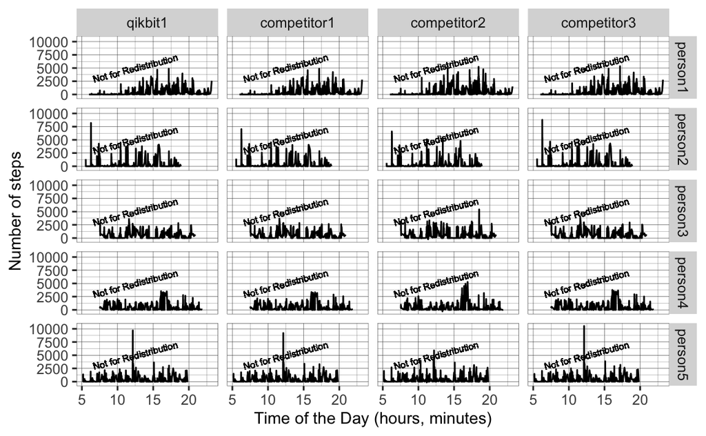

```r
qb_device_data$time <- as.numeric(paste0(qb_device_data$hours,".",
                                  qb_device_data$mins))
ggplot(qb_device_data) +
  aes(x = time, y = counts,) +
  geom_line() +
  facet_grid(id ~ device) +
  labs(
    x = "Time of the Day (hours, minutes)",
    y = "Number of steps",
    Title = "Number of steps for each person"
  ) +
  geom_text(
    x = 12.5,
    y = 5000,
    label = "Not for Redistribution",
    alpha = 0.2,
    angle = 15,
    size = 2
  ) +
  theme(
    panel.background = element_rect(fill = "white"),
    panel.grid = element_line(colour = "grey25", size = 0.1),
    panel.border = element_rect(colour = "grey25", size = 0.2, fill = NA),
    axis.title = element_text(size = 10),
    plot.title = element_text(size = 16),
    legend.title = element_text(size = 12),
    legend.text = element_text(size = 12)
    )
```